# Simulating hematopoietic phylogeny for SCM validation

Michael Tassia

2026-09-04

# Overview

The objective of this notebook is to document our validation strategy for applying stochastic character mapping (SCM) as a technique for reconstructing somatic genotype evolution given a phylogenetic tree, substitution model, and a data set of observed genotype states at the tips (see [*Bollback 2006*](https://link.springer.com/article/10.1186/1471-2105-7-88) and [*Revell 2024*](https://peerj.com/articles/16505/)). As a ground-truth somatic phylogeny data set does not yet exist, we will leverage simulation as a framework for validation.

This notebook will first describe the approach, key functions, and expected outcomes. Afterwards, additional layers of technical and biological variation will be introduced, including:

- Sample size
- Sequencing depth
- Missing data
- Collapsing branch lengths equal to 0
- Infinite sites model (ISM) violation rate

# Simulating hematopoiesis

We use the publicly available [`rsimpop` package](https://github.com/nangalialab/rsimpop) developed by Nick Williams at the Sanger Institute to simulate hematopoiesis under a birth-death model. This package implements the Gillespie algorithm (see [here](https://lewiscoleblog.com/gillespie-algorithm) for basic overview) to simulate cellular compartments under a distribution of user-defined parameters and is described in the supplementary information of [*Mitchell et al. 2022*](https://www.nature.com/articles/s41586-022-04786-y#Sec32).

Here, we use `rsimpop` with parameters set following empirical estimates from the literature. Fitness coefficients manifest as bias toward symmetric division, and polygenic effects are assumed to be additive.

The libraries and functions used in this notebook are tracked in `simphy_functions.R`.

## Distribution of fitness effects (DFE)

`rsimpop` encodes fitness as increased rates of symmetric division (i.e., birth) for clones bearing a driver mutation. Here, we draw fitness effects from a gamma distribution using the parameters described in [Extended Data Fig 12 of *Mitchell et al. 2022*](https://www.nature.com/articles/s41586-022-04786-y/figures/17).

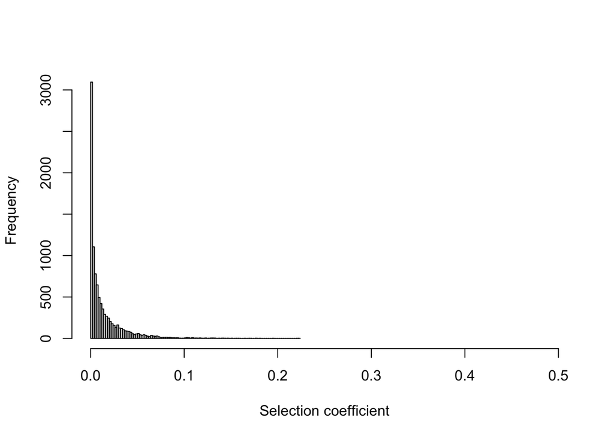

```r
SEED <- 1212121

# DFE function
fitnessFn <- genGammaFitness(shape = 0.47,
                             rate = 34,
                             seed = SEED)

# Plot DFE
hist(sapply(1:1e4, function(x) exp(fitnessFn()) - 1),
     breaks = 100, xlim = c(0, 0.5),
     xlab = "Selection coefficient", main = "")
```

## Simulate HSC population

Using the DFE above, we can simulate hematopoiesis with stochastic introduction of driver mutations using the `run_driver_process_sim()` wrapper in `rsimpop`. This function has several important parameters which will be defined below:

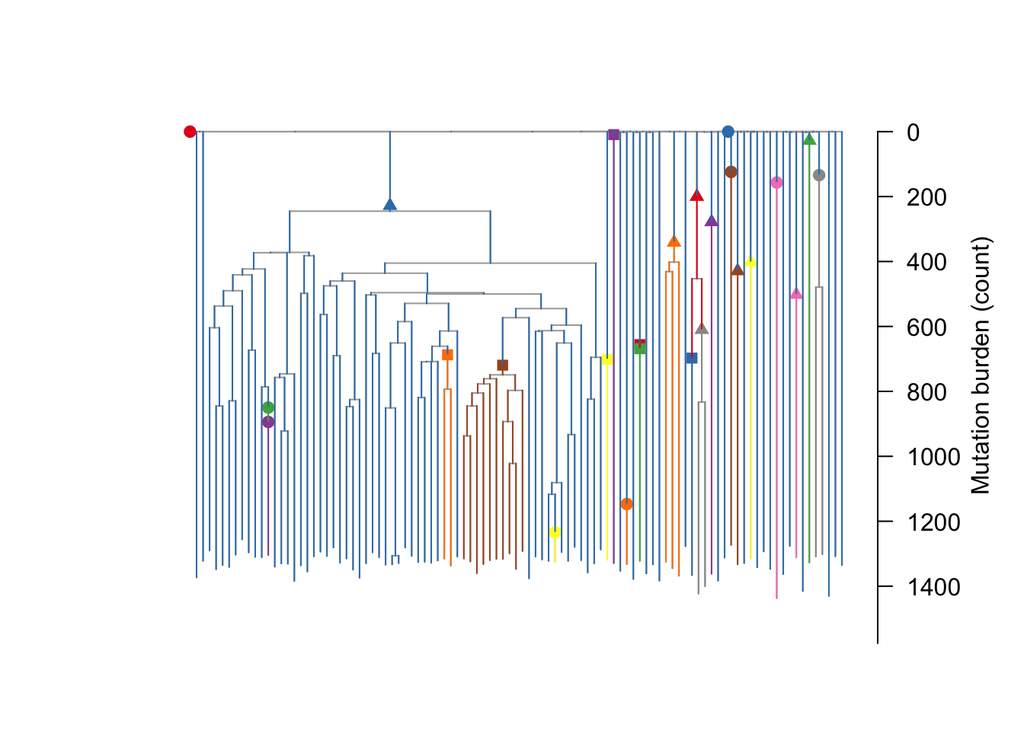

```r
# Simulation seed
initSimPop(SEED, bForce = TRUE)

# Run rsimpop
sim <- run_driver_process_sim(
  simpop                   = NULL,
  initial_division_rate    = 0.1,
  final_division_rate      = 1/365,
  target_pop_size          = 1e5,
  nyears                   = 80,
  fitness                  = fitnessFn,
  drivers_per_cell_per_day = 2.0e-3 / 365
)

# Sample 100 cells from the HSC population
st <- get_subsampled_tree(sim, 100)

# Re-scale the phylogeny by mutations
st_mut <- get_elapsed_time_tree(st,
                                mutrateperdivision = 0,
                                backgroundrate = 16.8/365)

# Plot driver events on the phylogeny
plot_tree_events(st_mut,
                 cex.label = 0,
                 legpos = NULL,
                 mar = c(3,3,3,5))
mtext("Mutation burden (count)", side = 4, line = 3)
```

From the simulated history, we need to extract the `phylo` object from the `simpop` output.

The `get_phylo_object()` function takes the output from `rsimpop::get_elapsed_time_tree()` and extracts the phylogenetic component while also propagating driver information into the `$driver_info` slot of the output. Below, we’ll plot the driver events drawn from the full population.

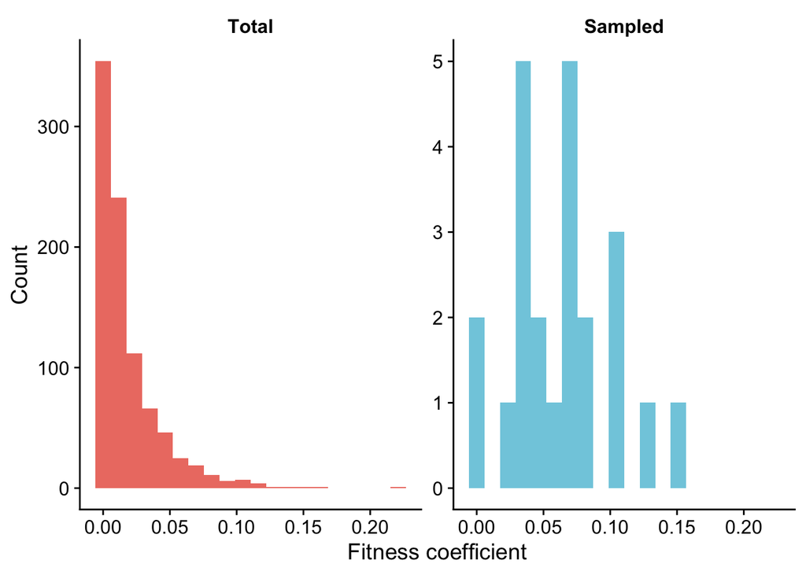

```r
# Get tree from simulation object
tr <- get_phylo_object(st_mut)

# Plot fitness distribution
sim$cfg$drivers %>%
  mutate(pop = "Total") %>%
  bind_rows(st_mut$cfg$drivers %>%
              mutate(pop = "Sampled")) %>%
  mutate(pop = factor(pop, levels = c("Total", "Sampled"))) %>%
  ggplot(aes(x = fitness, fill = pop)) +
  geom_histogram(alpha = 0.75,
                 position = "identity",
                 bins = 20) +
  scale_fill_npg(guide = "none") +
  facet_wrap(~pop, ncol = 2, scales = "free_y") +
  theme_cowplot() +
  theme(legend.position = "top",
        strip.background = element_blank(),
        strip.text = element_text(face = "bold")) +
  labs(x = "Fitness coefficient",
       y = "Count")
```

To compare this ground-truth tree (where branch lengths are scaled by the true mutation counts) against a molecular phylogeny, we need to re-scale these mutation counts by the size of the analyzable genome. Scaling will also account for the reduced genome access, as only genomic positions passing a genome-accessibility filter are the only loci realistically analyzed during phylogenetic inference (we use the [1000 Genomes Project GRCh38 strict accessibility mask](https://ftp.1000genomes.ebi.ac.uk/vol1/ftp/data_collections/1000_genomes_project/working/20160622_genome_mask_GRCh38/StrictMask/20160622.allChr.mask.bed)).

Note that the branch lengths produced using the methods above will be orders of magnitude smaller than the branch lengths fit by maximum-likelihood methods (e.g., `CellPhy`), as the latter are scaled to the number of sites in the alignment (not the whole genome). The `scale_branches_to_subs_per_site()` function reads a bed file and divides `$edge.length` by the sum of the masked region.

```
  Sample tree's L: 89503
```

```
Rescaled tree's L: 3.925e-05
```

## Extracting mutation history truth

`rsimpop` tracks mutation origin alongside the “ground truth” simulated history; thus, we can use these mutations to reconstruct a VCF-like structure that can later be used for SCM validation.

```r
# Extract phyletic patterns per mutation
mut_mat <- create_mut_df(tr)

# Preview mutation matrix
mut_mat %>%
  filter(is_driver) %>%
  select(1:9) %>%
  head() %>%
  knitr::kable()
```

| mutation_id | is_driver | selection_coefficient | is_ism_violation | n_origins | edge | s1 | s2 | s3 |
| --- | --- | --- | --- | --- | --- | --- | --- | --- |
| 9eab5e106b97 | TRUE | 0.1561443 | FALSE | 1 | 12 | 0 | 0 | 0 |
| ff5d4ba6c61c | TRUE | 0.0028901 | FALSE | 1 | 33 | 0 | 0 | 0 |
| 68428b295a3b | TRUE | 0.0373747 | FALSE | 1 | 33 | 0 | 0 | 0 |
| 146bbd275beb | TRUE | 0.0043295 | FALSE | 1 | 87 | 0 | 0 | 0 |
| 2aff399e0e13 | TRUE | 0.0710599 | FALSE | 1 | 93 | 0 | 0 | 0 |
| 57744887c3ef | TRUE | 0.0220982 | FALSE | 1 | 122 | 0 | 0 | 0 |

The `create_mut_df()` function above takes the subsampled `phylo` object output by `get_phylo_object()` to create a data frame, where records correspond to “mutations”, and fields are defined as follows (in order):

1. `mutation_id <chr>:` unique hash identifier for each record
2. `is_driver <lgl>:` Boolean for whether record is a driver mutation
3. `selection_coefficient <dbl>:` fitness coefficient, $s$, if `is_driver == TRUE`; otherwise `NA`
4. `is_ism_violation <lgl>:` Boolean for whether a record corresponds to an ISM violation
5. `n_origins <int>`: Number of true origins for record
6. `edge <chr>`: Edge number (in input `phylo` order) for record’s origin(s).
7. `[s1, s2, ..., sN+1] <dbl>`: Remaining mutation array encoded with presence/absence (`1` or `0`) for whether the mutation is inherited by the tip. As an outgroup (without any mutation) is always introduced by `get_subsampled_tree()`, the number of fields in this component of the dataframe will equal $N + 1$.

Thus, for $N$ sampled tips and a total tree length of $V$ (i.e., $V$ mutations), the resulting data frame will be $(N + 7)\times V$ (6 metadata columns plus $N+1$ sample columns, per points 1-7 above). Note that introducing ISM violations will reduce the total matrix size, as `introduce_ism_violations()` merges records (see Simulating ISM violations below).

The combination of `$edge` and the mutation array patterns can be used to trace a mutation’s ancestry. For example:

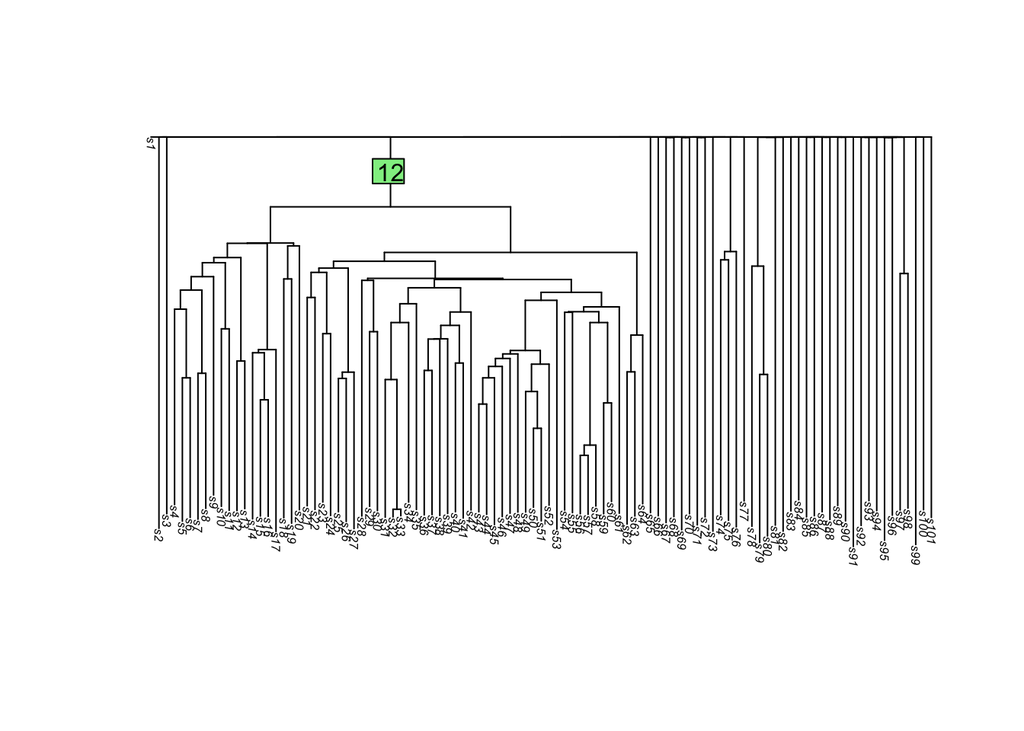

```
Mutation events on edge 12 are inherited by the following tips:
 s4 to s64
```

The extension of this approach for ISM violations ($\ge 2$ origins) will be discussed in Simulating ISM Violation below.

## Simulating sequence-read data

The output of `create_mut_df()` is then passed to the `simulate_DP_and_AD()` function to simulate sequence-read data. Default parameters are set such that they mimic the structure of “cleaned” data described in [*Coorens et al. 2025*](https://www.nature.com/articles/s41596-024-00962-8)and/or modeled distribution parameters in [*Mitchell et al. 2022*](https://www.nature.com/articles/s41586-022-04786-y).

- `G`: Matrix output by `create_mut_df()`
- `D_bar = 20`: Target mean sequencing depth across the whole matrix
- `min_cov = 6`: Lower depth bound a site must clear to pass QC (Sequoia-style `min_cov`)
- `max_cov = 250`: Upper depth bound (excludes repeat/mapping-artifact loci)
- `site_sdlog = 0.5`: Log-scale spread of per-site coverage bias (GC/mappability)
- `sample_sdlog = 0.3`: Log-scale spread of per-sample library depth variation
- `theta = 8`: Negative-binomial dispersion for residual (post-QC) depth noise
- `rho_max = 0.1`: Beta-binomial overdispersion ceiling a site must clear (Sequoia snv_rho)
- `site_conc_shape = 4`: Gamma shape for the distribution of per-site VAF concentration
- `site_conc_rate = 0.3`: Gamma rate for the distribution of per-site VAF concentration
- `error_rate = 0.002`: Sequencing/mapping error rate (alt reads at true hom-ref sites)
- `dropout_rate = 0.00`: $P(\textrm{complete allelic dropout} | \textrm{truly heterozygous site})$

```r
sim_reads <- simulate_DP_and_AD(G = mut_mat,
                                seed = SEED)
glimpse(sim_reads)
```

```
List of 7
 $ DP           : num [1:89503, 1:101] 37 14 14 35 31 6 36 8 16 14 ...
  ..- attr(*, "dimnames")=List of 2
  .. ..$ : NULL
  .. ..$ : chr [1:101] "s1" "s2" "s3" "s4" ...
 $ AD           : int [1:89503, 1:101] 0 0 0 0 0 0 0 0 0 0 ...
  ..- attr(*, "dimnames")=List of 2
  .. ..$ : NULL
  .. ..$ : chr [1:101] "s1" "s2" "s3" "s4" ...
 $ site_factor  : num [1:89503] 1.363 1.048 0.531 2.209 1.331 ...
 $ sample_factor: num [1:101] 1.119 1.15 0.851 0.907 0.893 ...
 $ site_conc    : num [1:89503] 13.1 26.6 15.6 10.9 14.4 ...
 $ site_rho     : num [1:89503] 0.0708 0.0362 0.0603 0.0843 0.0649 ...
 $ dropout      : logi [1:89503, 1:101] FALSE FALSE FALSE FALSE FALSE FALSE ...
  ..- attr(*, "dimnames")=List of 2
  .. ..$ : NULL
  .. ..$ : chr [1:101] "s1" "s2" "s3" "s4" ...
```

The `simulate_DP_and_AD()` function will generate a list with the following slots:

- `$DP` [**stochastic**]: Data frame containing simulated sequence depth at each site $v$ per sample $n$. Thus, $\texttt{DP}_{nv} \sim \textrm{NB} (\mu_{nv} = \texttt{sample_factor}_n \times \texttt{site_factor}_v, \theta = \texttt{theta})$
- `$AD` [**stochastic**]: Data frame containing simulated variant allele depth at each site $v$ per sample $n$. For samples without mutation, $\texttt{AD}_{nv} \sim \textrm{Binom}(n = \texttt{DP}_{nv}, p = \texttt{error_rate})$. For samples bearing mutation, $\texttt{AD}_{nv} \sim \textrm{Binom}(n = \texttt{DP}_{nv}, p \sim Beta(\alpha = \beta = \frac{1}{2}\texttt{site_conc}_{nv}))$
- `$site_factor` [**stochastic**]: Vector containing scaling factors for each $v$ simulated loci; $\texttt{site_factor}_v \sim \textrm{LogN}_{tr} (\mu = 0, \sigma = \texttt{sigma_v}, a = \frac{\texttt{min_cov}}{\texttt{D_bar}}, b = \frac{\texttt{max_cov}}{\texttt{D_bar}})$
- `$sample_factor` [**stochastic**]: Vector containing scaling factors for each $n + 1$ sampled tips ($+1$ for the added outgroup); $\texttt{sample_factor}_n \sim \textrm{LogN}_{tr} (\mu = 0, \sigma = \sigma_v, a = \frac{\texttt{min_cov}}{\texttt{D_bar}}, b = \infty)$
- `$site_conc` [**stochastic**]: Vector containing symmetric beta distribution shape parameters used to simulate `$AD` at each $NV$ site; $\texttt{site_conc}_v \sim \Gamma_{tr}(\alpha = \texttt{site_conc_shape}, \beta = \texttt{site_conc_rate},a = \frac{(1 - \texttt{rho_max})}{\texttt{rho_max}},b = \infty)$
- `$site_rho` [**deterministic**]: Beta-binomial’s $\rho$ parameter for each $v$ site; $\rho_{v} = \frac{1}{(1 + \texttt{site_conc}_v)}$
- `$dropout` [**stochastic**]: Boolean vector for whether a sample $n$ experiences allelic dropout at site $v$.

Below, we’ll visualize the realized distribution of mean read depth across all sites and samples under the function’s default parameters.

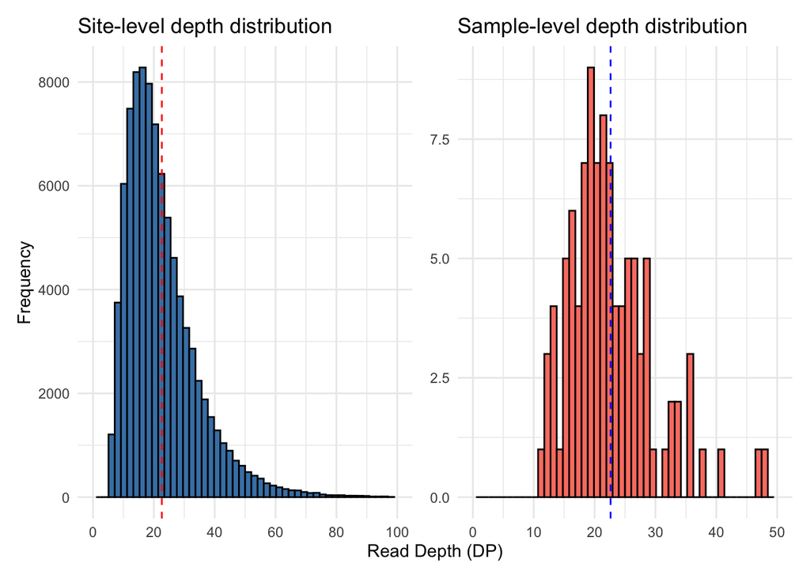

From the `simulate_DP_and_AD()` output (`<list>`), the `$AD` and `$DP` slots are used to compute Phred-scaled genotype likelihoods following the fixed-error-rate GATK model ([DePristo et al. 2011](https://www.nature.com/articles/ng.806)).

```r
sim_genotypes <- simulate_GQ_PL_GT(AD = sim_reads$AD,
                                   DP = sim_reads$DP)
glimpse(sim_genotypes)
```

```
List of 5
 $ GQ : num [1:89503, 1:101] 99 42 42 99 93 18 99 24 48 42 ...
  ..- attr(*, "dimnames")=List of 2
  .. ..$ : NULL
  .. ..$ : chr [1:101] "s1" "s2" "s3" "s4" ...
 $ PL0: num [1:89503, 1:101] 0 0 0 0 0 0 0 0 0 0 ...
  ..- attr(*, "dimnames")=List of 2
  .. ..$ : NULL
  .. ..$ : chr [1:101] "s1" "s2" "s3" "s4" ...
 $ PL1: num [1:89503, 1:101] 111 42 42 105 93 18 108 24 48 42 ...
  ..- attr(*, "dimnames")=List of 2
  .. ..$ : NULL
  .. ..$ : chr [1:101] "s1" "s2" "s3" "s4" ...
 $ PL2: num [1:89503, 1:101] 255 255 255 255 255 255 255 255 255 255 ...
  ..- attr(*, "dimnames")=List of 2
  .. ..$ : NULL
  .. ..$ : chr [1:101] "s1" "s2" "s3" "s4" ...
 $ GT : chr [1:89503, 1:101] "0/0" "0/0" "0/0" "0/0" ...
  ..- attr(*, "dimnames")=List of 2
  .. ..$ : NULL
  .. ..$ : chr [1:101] "s1" "s2" "s3" "s4" ...
```

Finally, we will sample sites from the human genome and assign these to the records held in `sim_genotypes`. These sites will then be threaded into a function to create a [VCF-like](https://gatk.broadinstitute.org/hc/en-us/articles/360035531692-VCF-Variant-Call-Format) data frame. Later, this VCF-like data structure will be exported as a VCF file that can be used as input for SCM.

```r
mut_table <- sample_mutation_loci(nrow(sim_genotypes$GT),
                                  seed = SEED)
vcf_df <- build_vcf_df(G = mut_mat,
                       DP = sim_reads$DP,
                       AD = sim_reads$AD,
                       gl = sim_genotypes,
                       edges = mut_mat$edge,
                       mut_table = mut_table)

glimpse(head(vcf_df,1)[1:11])
```

```
Rows: 1
Columns: 11
$ CHROM  <chr> "chr12"
$ POS    <int> 15544219
$ ID     <chr> "0d388541cac6"
$ REF    <chr> "C"
$ ALT    <chr> "T"
$ QUAL   <chr> "."
$ FILTER <chr> "PASS"
$ INFO   <chr> "AC=1;AF=0.0049505;EDGE=10;DRIVER=0;S=0;ISM_VIOL=0;N_ORIGINS=1"
$ FORMAT <chr> "GT:DP:AD:GQ:PL:TG"
$ s1     <chr> "0/0:37:37,0:99:0,111,255:0"
$ s2     <chr> "0/1:18:5,13:99:255,0,255:1"
```

Note that the VCF-like structure may contain some records with unobserved variants in the sampled population due to the stochastic nature of `simulate_DP_and_AD()`:

```r
vcf_df %>%
  filter(grepl(x = INFO, pattern = "AC=0")) %>%
  dplyr::select(1,2,4,5,8) %>%
  head(n = 5) %>%
  knitr::kable()
```

| CHROM | POS | REF | ALT | INFO |
| --- | --- | --- | --- | --- |
| chr13 | 33645441 | G | C | AC=0;AF=0;EDGE=10;DRIVER=0;S=0;ISM_VIOL=0;N_ORIGINS=1 |
| chrX | 78555312 | C | G | AC=0;AF=0;EDGE=10;DRIVER=0;S=0;ISM_VIOL=0;N_ORIGINS=1 |
| chr15 | 65459218 | C | A | AC=0;AF=0;EDGE=10;DRIVER=0;S=0;ISM_VIOL=0;N_ORIGINS=1 |
| chr3 | 53168563 | G | C | AC=0;AF=0;EDGE=10;DRIVER=0;S=0;ISM_VIOL=0;N_ORIGINS=1 |
| chr12 | 18026175 | A | T | AC=0;AF=0;EDGE=10;DRIVER=0;S=0;ISM_VIOL=0;N_ORIGINS=1 |

The VCF-like data frame can be exported as a VCF file with `write_vcf_df()`; we will write the ground-truth molecular phylogeny to file alongside it.

```r
write_vcf_df(vcf_df %>% filter(!grepl(x = INFO,
                                      pattern = "AC=0")),
             file = "test_sim/test_sim.vcf",
             tree = tr)
write.tree(tr_mol, file = "test_sim/test_sim.nwk")
```

# Testing the SCM framework on simulated data

Given the simulated tree and somatic variants above, SCM can be performed to infer the evolutionary history of somatic variants given simulated read data. Here, we’ll use the ground truth tree and just test the performance of SCM in reproducing each variant’s origin on the tree. In practice, SCM would be performed on a molecular phylogeny inferred from the VCF file above.

The three critical components for modeling somatic SNVs with SCM are (1) the phylogeny with branch lengths measured in substitutions per site, (2) the VCF file with somatic SNVs and their associated confidence metrics (`PL` scores), and (3) a genotype substitution model fit to the phylogeny. Below, we’ll use a substitution model fit with `CellPhy` to the ground truth tree and the observed data.

The `CellPhy` command for fitting unphased genotype substitution model ($Q_{GT10}$) parameters, $\theta$ , is the following:

```
cellphy.sh \
    RAXML \
    --evaluate \
    --msa path/to/test_sim.vcf \
    --msa-format vcf \
    --model GT10+FO \
    --tree path/to/test_sim.nwk \
    --prefix cellphy \
    --threads 8 \
    --force perf_threads
```

## Validating SCM output with “ground-truth” tree

The SCM Snakemake pipeline was run on the simulated data above with 100 SCM replicates per record. Below, we’ll compare the count of **true mutations** generated along an edge to the count of **inferred mutations**.

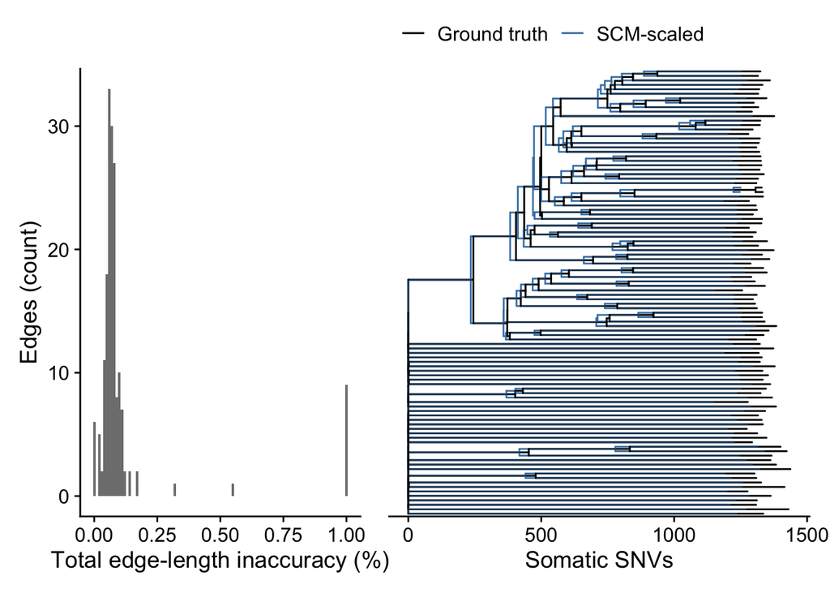

With the edge-wise summary above, we see that SCM *underestimates* edge lengths relative to ground truth. Underestimation may be due to either a preponderance of mutations that lack sufficient evidence to be assigned to the phylogeny **at all**, or mutations that are assigned to incorrect branches.

## Quantifying error

We first explore mutations that are not assigned at all to the phylogeny:

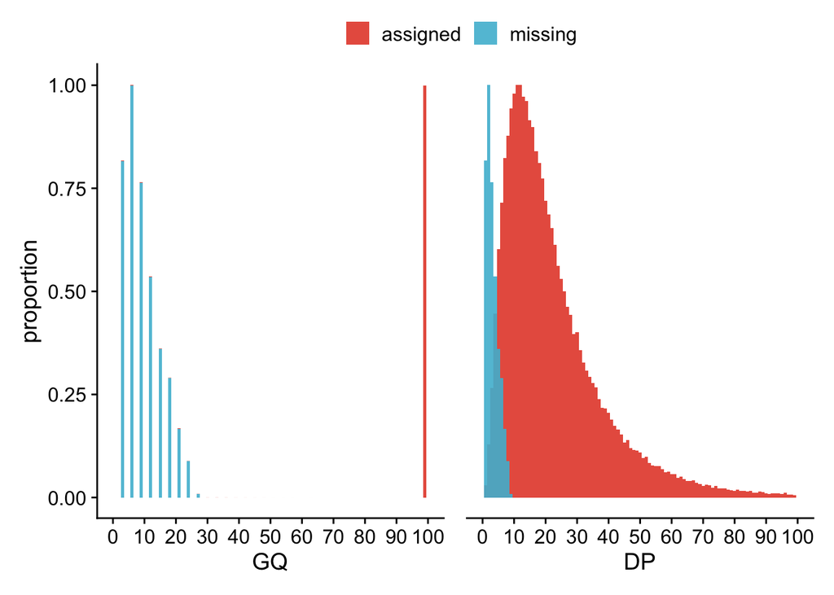

These plots show strong evidence that both `GQ` and `DP` scores stratify between mutations assigned and those missing from the tree. A Mann-Whitney U test for either quantity is statistically significant ($p=$ 1.05^{-273} and 0, respectively). This conservative quality of SCM, while limiting the total precision of the inferred history relative to ground-truth, is nonetheless valuable for accuracy.

Next, we assess concordance between the SCM-inferred origins for the mutations and compare to ground truth. To achieve this, we can measure whether each mutation shares the same bipartitions between the **ground truth** and **inferred** history. This approach leverages the function `compare_scm_edges()`, a wrapper for several other functions that computes the bipartitions for each `sim_tree` and `scm_tree` inputs, matches both topologies by these bipartitions, and then computes the distance between the **inferred** edge(s) and the **ground truth** edge(s).

```
[1] "Edge-mapping concordance: 0.998"
```

Here, we measure distance as a one-sided, nearest-neighbor sum from inferred edges to truth edges:
$$\Delta(S,T) = \sum_{e \in S}\min_{t \in T}d(t,e),$$

where $S = {e_1, \dots, e_k}$ is the set of SCM-inferred edges for a mutation and $T = t_1, \dots, t_m$ is the set of valid edges that can be assigned for a mutation. Since we use SCM to assign mutations to *edges*, not nodes, $d(\cdot,\cdot)$ is the **line-graph (edge-adjacency) distance**: the distance two edges would have as vertices of the tree’s line graph, where two edges are adjacent (distance 1) exactly when they share an endpoint node. Concretely, for edges $e=(p_e,c_e)$ and $f=(p_f,c_f)$ (parent node, child node),

$$d(e,f) = 1 + \min\big(d_{\text{node}}(p_e,p_f),\,
d_{\text{node}}(p_e,c_f),\, d_{\text{node}}(c_e,p_f),\,
d_{\text{node}}(c_e,c_f)\big), \quad e \neq f,$$

with $d(e,e)=0$ and $d_{\text{node}}(\cdot,\cdot)$ the node-to-node edge-count distance. This makes sibling edges $d = 1$ apart rather than $2$, and an edge and its immediate parent edge $d = 1$ apart as well.

To account for the tree topology in this metric (and bound the value $[0,1]$), we normalize by the tree’s line-graph diameter $D$ – the largest $d(e,f)$ between any two edges of the tree – times the number of inferred edges. Thus,

$$\Delta_{norm}(S,T) = \frac{1}{|S| \times D}\sum_{e \in S}\min_{t \in
T}d(t,e) \in [0,1].$$

A value of $0$ reflects inference completely concordant with truth, and a value of $1$ corresponds to an inferred history as far as two edges can possibly be from one another (given the tree’s topology).

A visual example of this metric is provided below:

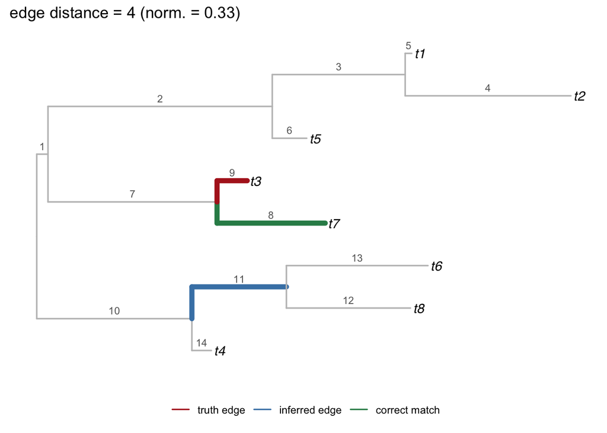

Below is a histogram of these distance metrics for mutations with discordant mapping(s):

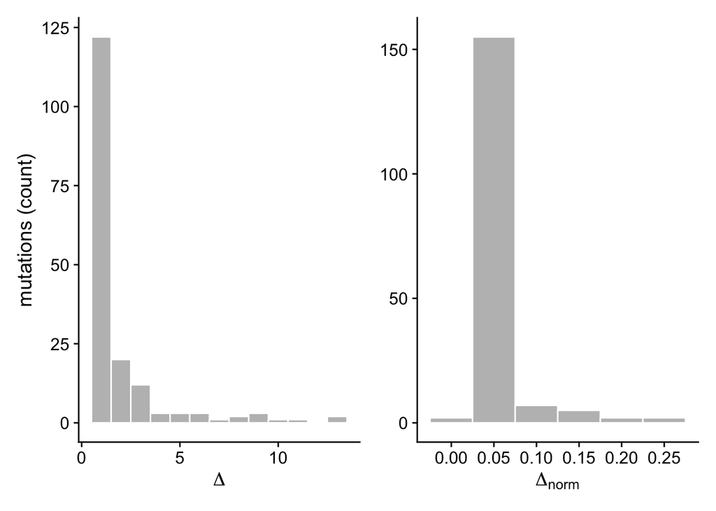

| sample | GT | DP | AD | GQ | PL |
| --- | --- | --- | --- | --- | --- |
| s4 | 0/1 | 4 | 2,2 | 99 | 255,0,255 |
| s5 | 0/0 | 4 | 4,0 | 12 | 0,12,255 |
| s6 | 0/1 | 16 | 8,8 | 99 | 255,0,255 |
| s7 | 0/1 | 12 | 4,8 | 99 | 255,0,255 |
| s8 | 0/1 | 5 | 1,4 | 99 | 255,0,255 |
| s9 | 0/0 | 8 | 8,0 | 24 | 0,24,255 |

If we visualize the **true origin** of the mutation (blue) and compare to the **inferred origin (red)**, the result is consistent with the sparse evidence in the VCF.

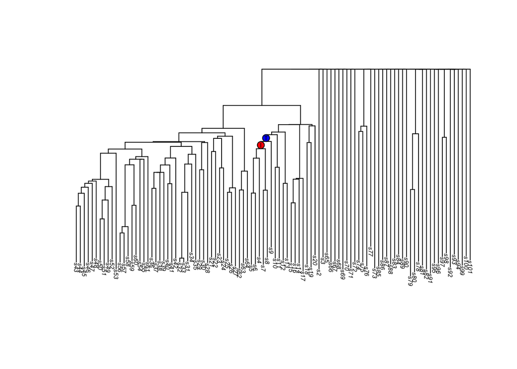

If we aggregate across all mutations that were mismapped to a single branch (i.e., these are mutations with single origins and inferred to have a single origin, only misplaced relative to truth) and aggregate simulated sequence read information, we observe the following:

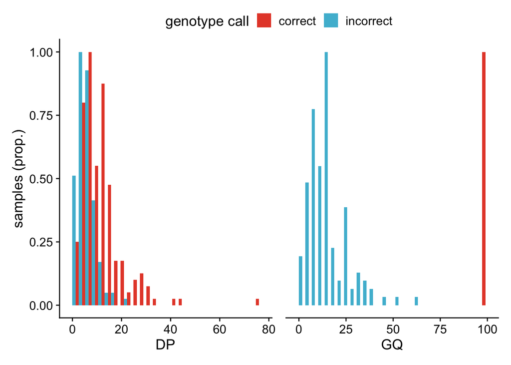

This observation motivates stringent filtering at the scale of genotype quality.

### False-positive ISM violations

If we stratify all the incorrectly mapping variants by the number of edges that they map to, we see that some false-positive ISM violations are recovered with SCM:

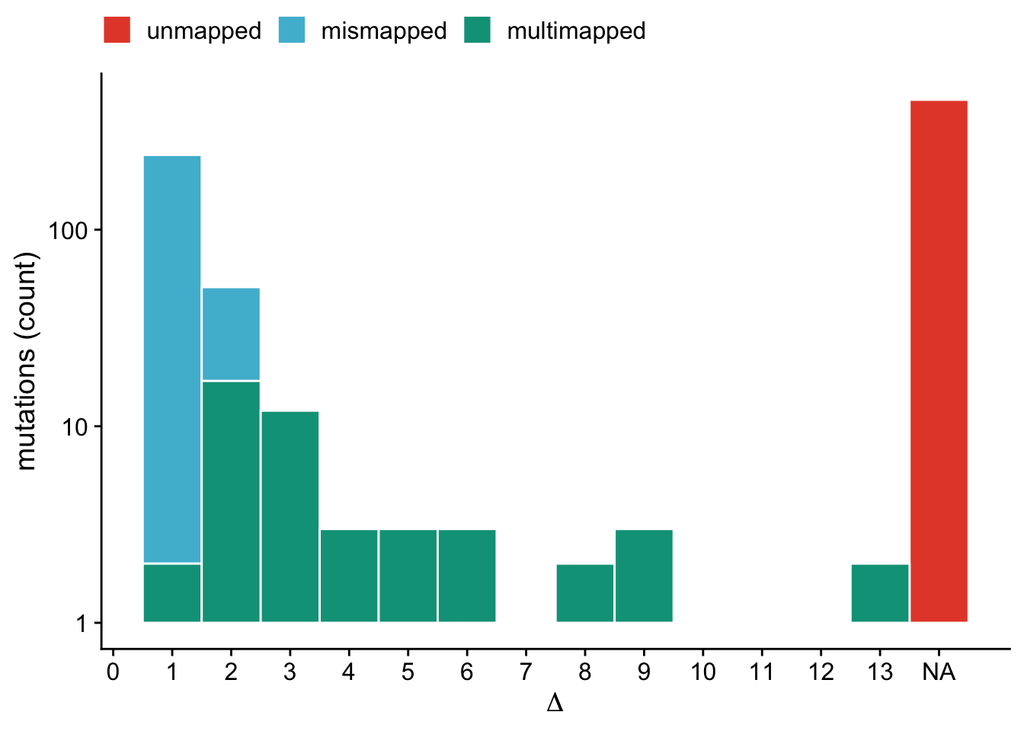

If we isolate only the multimapping mutations (i.e., false-positive ISM violations):

```r
incorrect.df %>%
  filter(n_assigned > 1) %>%
  knitr::kable()
```

| locus | true_edge | assigned_edge | n_assigned | correct | d | dnorm | error_class |
| --- | --- | --- | --- | --- | --- | --- | --- |
| chr12:72239308 | 7 | 7,107 | 2 | FALSE | 8 | 0.1428571 | multimapped |
| chr17:77872707 | 7 | 7,103 | 2 | FALSE | 9 | 0.1607143 | multimapped |
| chr2:225892804 | 7 | 7,21 | 2 | FALSE | 13 | 0.2321429 | multimapped |
| chr15:89592799 | 7 | 7,21 | 2 | FALSE | 13 | 0.2321429 | multimapped |
| chr4:46051725 | 7 | 7,39 | 2 | FALSE | 11 | 0.1964286 | multimapped |
| chr3:177612744 | 7 | 7,125 | 2 | FALSE | 4 | 0.0714286 | multimapped |
| chr2:46472907 | 7 | 7,58 | 2 | FALSE | 9 | 0.1607143 | multimapped |
| chr8:35155664 | 7 | 7,127 | 2 | FALSE | 3 | 0.0535714 | multimapped |
| chr7:68468921 | 95 | 95,126 | 2 | FALSE | 3 | 0.0535714 | multimapped |
| chr12:10966911 | 95 | 95,115 | 2 | FALSE | 4 | 0.0714286 | multimapped |
| chr4:38911966 | 95 | 95,111 | 2 | FALSE | 5 | 0.0892857 | multimapped |
| chr11:123429450 | 95 | 95,125 | 2 | FALSE | 3 | 0.0535714 | multimapped |
| chr17:33654055 | 95 | 95,126 | 2 | FALSE | 3 | 0.0535714 | multimapped |
| chr4:61923131 | 101 | 101,103 | 2 | FALSE | 2 | 0.0357143 | multimapped |
| chr20:15333073 | 101 | 104,105 | 2 | FALSE | 3 | 0.0535714 | multimapped |
| chr1:102802564 | 116 | 116,121 | 2 | FALSE | 2 | 0.0357143 | multimapped |
| chr14:28516188 | 117 | 116,122 | 2 | FALSE | 2 | 0.0357143 | multimapped |
| chr20:21780524 | 117 | 119,121 | 2 | FALSE | 3 | 0.0535714 | multimapped |
| chr7:89384657 | 117 | 116,122 | 2 | FALSE | 2 | 0.0357143 | multimapped |
| chr4:124454443 | 117 | 116,122 | 2 | FALSE | 2 | 0.0357143 | multimapped |
| chr1:203531553 | 8 | 8,48 | 2 | FALSE | 6 | 0.1071429 | multimapped |
| chr14:21905789 | 8 | 8,46 | 2 | FALSE | 8 | 0.1428571 | multimapped |
| chr3:35321023 | 8 | 8,83 | 2 | FALSE | 5 | 0.0892857 | multimapped |
| chr6:149849987 | 8 | 8,57 | 2 | FALSE | 9 | 0.1607143 | multimapped |
| chr9:107826613 | 9 | 9,61 | 2 | FALSE | 7 | 0.1250000 | multimapped |
| chr12:116992936 | 85 | 85,88 | 2 | FALSE | 2 | 0.0357143 | multimapped |
| chr1:165698466 | 10 | 10,21 | 2 | FALSE | 10 | 0.1785714 | multimapped |
| chr2:31597181 | 49 | 49,61 | 2 | FALSE | 4 | 0.0714286 | multimapped |
| chr2:196238637 | 63 | 68,71 | 2 | FALSE | 5 | 0.0892857 | multimapped |
| chr2:119709145 | 63 | 65,71 | 2 | FALSE | 3 | 0.0535714 | multimapped |
| chr2:29421865 | 53 | 54,57 | 2 | FALSE | 2 | 0.0357143 | multimapped |
| chr3:13697752 | 12 | 12,40 | 2 | FALSE | 6 | 0.1071429 | multimapped |
| chr14:30570654 | 14 | 14,21 | 2 | FALSE | 6 | 0.1071429 | multimapped |
| chr11:85471880 | 45 | 46,47 | 2 | FALSE | 2 | 0.0357143 | multimapped |
| chr6:12446069 | 37 | 39,41 | 2 | FALSE | 3 | 0.0535714 | multimapped |
| chr12:33072896 | 90 | 90,94 | 2 | FALSE | 1 | 0.0178571 | multimapped |
| chr16:52446153 | 90 | 92,94 | 2 | FALSE | 3 | 0.0535714 | multimapped |
| chr7:27543276 | 134 | 135,136 | 2 | FALSE | 2 | 0.0357143 | multimapped |
| chr19:30608055 | 137 | 138,139 | 2 | FALSE | 2 | 0.0357143 | multimapped |
| chr2:22363270 | 137 | 138,139 | 2 | FALSE | 2 | 0.0357143 | multimapped |
| chr8:43481279 | 140 | 141,142 | 2 | FALSE | 2 | 0.0357143 | multimapped |
| chr5:85132070 | 140 | 141,142 | 2 | FALSE | 2 | 0.0357143 | multimapped |
| chr3:189736622 | 145 | 147,149 | 2 | FALSE | 3 | 0.0535714 | multimapped |
| chr11:119825292 | 145 | 148,149 | 2 | FALSE | 3 | 0.0535714 | multimapped |
| chr10:37562122 | 145 | 148,149 | 2 | FALSE | 3 | 0.0535714 | multimapped |
| chr2:13074270 | 146 | 147,148 | 2 | FALSE | 2 | 0.0357143 | multimapped |
| chr14:42711707 | 174 | 174,175 | 2 | FALSE | 1 | 0.0178571 | multimapped |
| chr1:92902891 | 159 | 160,161 | 2 | FALSE | 2 | 0.0357143 | multimapped |
| chr3:196014518 | 162 | 163,164 | 2 | FALSE | 2 | 0.0357143 | multimapped |
| chr2:4236126 | 184 | 185,186 | 2 | FALSE | 2 | 0.0357143 | multimapped |

### Effect of branch length

As SCM simulates genotype evolution according to a continuous-time Markov chain modeled as a Poisson process, the probability that a mutation occurs along an edge and that edge’s length are exponentially related where,

$$f(t) = \lambda e^{-\lambda t}, ~~~ \lambda = -q_{ii}.$$

In this context, $t$ is the edge length (measured in molecular time: substitutions per site) and $-q_{ii}$ is the diagonal element of the genotype substitution matrix $Q$ in state $i$. This example is pulled directly from equation 4 in [Bollback et al. 2006](https://pmc.ncbi.nlm.nih.gov/articles/PMC1403802/). Because we only simulate mutations that transition unphased genotypes from homozygous to heterozygous states, we will plot the relationship between edge length and the unconditional state transition probability for [A/A, C/C, G/G, T/T] below:

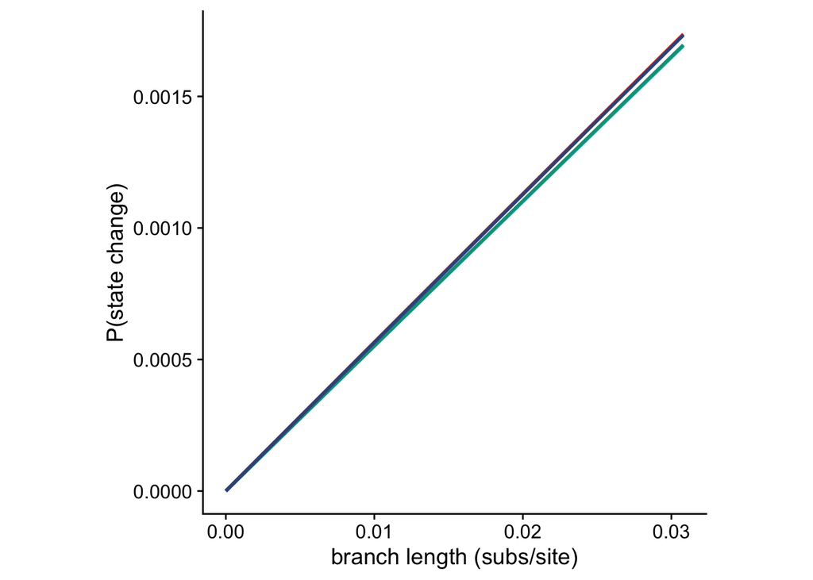

However, when we plot the relationship between mapping accuracy and edge length, we see relatively stable performance – this will require further validation across a larger posterior distribution of simulations.

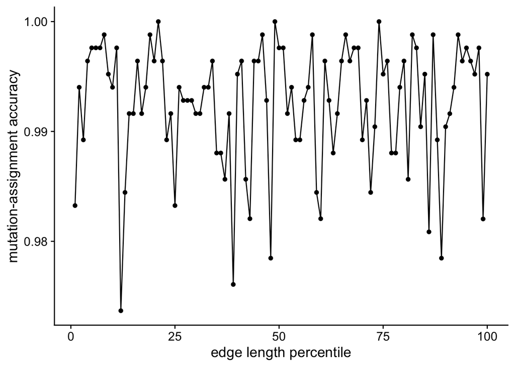

# Simulating ISM violations

To avoid changing the source code of `Rsimpop` to introduce infinite sites model (ISM) violations at the cellular dynamics phase, ISM violations will instead be introduced **post-hoc**. To accommodate the differential effects of mutations on the phylogenetic history of each simulated population, ISM violations will be introduced in a fashion that matches on fitness coefficients.

## Background

To start with, we’ll use the principles of the birthday paradox to estimate the expected count of ISM violations to introduce into the population. Notably, we’ll assume a fixed mutation rate across the simulated genome, but in practice, mutation rate heterogeneity is a focal research topic in this study. The simulated history above assumes a fixed somatic mutation rate across the genome ($\mu = 16.8 \: \textrm{SNVs per cell per year}$), and here we estimate the expected count of ISM violations, $x$, using,

$$E[\textrm{ISM Violations}] \approx
\frac{(\sum_{i}v_i)^2}{2L},$$

where $\sum_{i}v_i$ is the total branch length of the sub-sampled phylogeny (measured in mutations) and $2L$ is the diploid genome size ($\approx 6.4 \: \textrm{gigabases}$). In the phylogeny simulated above, this evaluates to an expected 2 ISM violations.

## Introducing ISM violations

Below, we’ll use both this predicted value and/or a fixed value to introduce ISM violations into the data frame output of `create_mut_df()`. A plot is generated reflecting an example for the ISM violations introduced on the phylogeny.

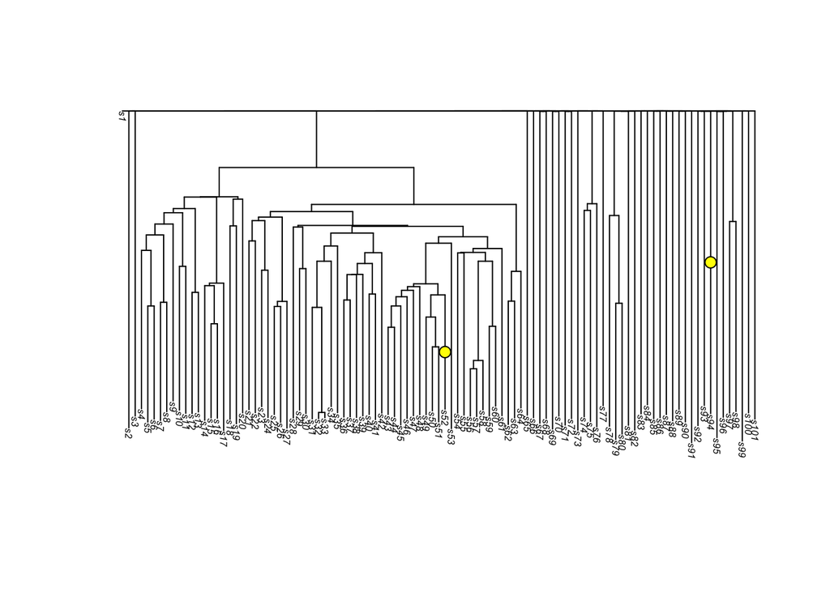

```r
# Create a `violation_spec` df to specify ism violations for introduction
viols <- data.frame(n_origins = 2,
                    count = estimate_ism_violations(tr))

# Broadcase violations onto mut_mat
mut_mat.viol <- introduce_ism_violations(mut_df = mut_mat,
                         violation_spec = viols,
                         seed = SEED)

# Pull example for plotting
example_viol <- mut_mat.viol %>%
  filter(is_ism_violation) %>%
  head(n = 1) %>%
  pull(edge) %>%
  str_split(pattern = ",") %>%
  unlist() %>%
  as.integer()

# Plot example violation origins
plot.phylo(tr, direction = "downwards", cex = 0.5)
edgelabels(edge = example_viol,
           frame = "circle",
           bg = "yellow",
           text = rep("", 2),
           cex = 0.5)
```

From here, the whole pipeline can be repeated to generate a ground truth dataset with ISM violations for SCM:

```r
# Simulate reads from mut_mat.viol
sim_reads.viol <- simulate_DP_and_AD(G = mut_mat.viol,
                                     seed = SEED)

# Approximate uncertainty for sim_reads
sim_genotypes.viol <- simulate_GQ_PL_GT(AD = sim_reads.viol$AD,
                                        DP = sim_reads.viol$DP)

# Simulate mutation loci
mut_table.viol <- sample_mutation_loci(nrow(sim_genotypes.viol$GT),
                                       seed = SEED)

# Build VCF structure
vcf_df.viol <- build_vcf_df(G = mut_mat.viol,
                            DP = sim_reads.viol$DP,
                            AD = sim_reads.viol$AD,
                            gl = sim_genotypes.viol,
                            edges = mut_mat.viol$edge,
                            mut_table = mut_table.viol)

# Write VCF structure to file
write_vcf_df(vcf_df.viol %>% filter(!grepl(x = INFO,
                                      pattern = "AC=0")),
             file = "test_sim/test_sim.viol.vcf",
             tree = tr)

# Write tree to file
write.tree(tr_mol, file = "test_sim/test_sim.viol.nwk")
```

## Testing ISM violation comparisons

**Pending.** This section will repeat the edge-mapping concordance and error-diagnostic analyses from Testing the SCM framework on simulated data – `compare_scm_edges()`, the placement-error histograms, and the branch-length-accuracy plot – against the `vcf_df.viol`/`test_sim.viol.*` outputs generated above, once the corresponding SCM run on the ISM-violation dataset has been produced.